# Group 4 - Salary Prediction

Akash Gobalarajah, Cyril Alain Scheurmann, Keijo Alexander Nierula, Roman Krass

2024.03.14

# Project Setup

```r
# Set seed
set.seed(7)

# Importing data
load("data_wage.RData")
salaryData <- data
```

# Checking data for NA values

In this part we check our data for missing values. This is important because missing values can cause problems in the analysis and can lead to wrong results.

**Click to expand NA results**

```r
# Check for missing values in each column of the data set and store the result in the "has_NAs" data frame
has_NAs = as.data.frame(apply(data, 2, function(x) any(is.na(x))))

# Map matching column names for a more readable output
colnames(has_NAs) = c("has_NA")

# Print the has_NAs data frame to check if there are any NA values in our data set
has_NAs
```

```
##                                                                                                                             has_NA
## gender                                                                                                                       FALSE
## age                                                                                                                          FALSE
## country                                                                                                                      FALSE
## education                                                                                                                    FALSE
## undergraduate_major                                                                                                          FALSE
## job_role                                                                                                                     FALSE
## industry                                                                                                                     FALSE
## years_experience                                                                                                             FALSE
## ML_atwork                                                                                                                    FALSE
## Activities_Analyze.and.understand.data.to.influence.product.or.business.decisions                                            FALSE
## Activities_Build.and.or.run.a.machine.learning.service.that.operationally.improves.my.product.or.workflows                   FALSE
## Activities_Build.and.or.run.the.data.infrastructure.that.my.business.uses.for.storing..analyzing..and.operationalizing.data  FALSE
## Activities_Build.prototypes.to.explore.applying.machine.learning.to.new.areas                                                FALSE
## Activities_Do.research.that.advances.the.state.of.the.art.of.machine.learning                                                FALSE
## Activities_None.of.these.activities.are.an.important.part.of.my.role.at.work                                                 FALSE
## Notebooks_Kaggle.Kernels                                                                                                     FALSE
## Notebooks_Google.Colab                                                                                                       FALSE
## Notebooks_Azure.Notebook                                                                                                     FALSE
## Notebooks_Google.Cloud.Datalab                                                                                               FALSE
## Notebooks_JupyterHub.Binder                                                                                                  FALSE
## Notebooks_None                                                                                                               FALSE
## cloud_Google.Cloud.Platform..GCP.                                                                                            FALSE
## cloud_Amazon.Web.Services..AWS.                                                                                              FALSE
## cloud_Microsoft.Azure                                                                                                        FALSE
## cloud_IBM.Cloud                                                                                                              FALSE
## cloud_Alibaba.Cloud                                                                                                          FALSE
## cloud_I.have.not.used.any.cloud.providers                                                                                    FALSE
## Programming_Python                                                                                                           FALSE
## Programming_R                                                                                                                FALSE
## Programming_SQL                                                                                                              FALSE
## Programming_Bash                                                                                                             FALSE
## Programming_Java                                                                                                             FALSE
## Programming_Javascript.Typescript                                                                                            FALSE
## Programming_Visual.Basic.VBA                                                                                                 FALSE
## Programming_C.C..                                                                                                            FALSE
## Programming_MATLAB                                                                                                           FALSE
## Programming_Scala                                                                                                            FALSE
## Programming_Julia                                                                                                            FALSE
## Programming_SAS.STATA                                                                                                        FALSE
```

[output cut: 24 more lines]

```
## data_Image.Data                                                                                                              FALSE
## data_Numerical.Data                                                                                                          FALSE
## data_Sensor.Data                                                                                                             FALSE
## data_Tabular.Data                                                                                                            FALSE
## data_text.Data                                                                                                               FALSE
## data_Time.Series.Data                                                                                                        FALSE
## data_Video.Data                                                                                                              FALSE
## explainability.model_Examine.individual.model.coefficients                                                                   FALSE
## explainability.model_examine.feature.correlations                                                                            FALSE
## explainability.model_Examine.feature.importances                                                                             FALSE
## explainability.model_Create.partial.dependence.plots                                                                         FALSE
## explainability.model_LIME.functions                                                                                          FALSE
## explainability.model_SHAP.functions                                                                                          FALSE
## explainability.model_None.I.do.not.use.these.model.explanation.techniques                                                    FALSE
## wage                                                                                                                         FALSE
```

As we can see from the output above none of the columns contain any missing values. This is very good so we don’t have to deal with the problem of missing values.

# 1 Data description

```r
dim(data)
```

```
## [1] 10809    78
```

The `dim` function shows us, that we have 10’809 and 78 variables in our data set.

**Click to expand to see data structure**

```r
# Check the structure of the data
str(data)
```

```
## 'data.frame':    10809 obs. of  78 variables:
##  $ gender                                                                                                                     : Factor w/ 4 levels "Female","Male",..: 1 2 2 2 2 1 2 2 2 1 ...
##  $ age                                                                                                                        : Factor w/ 12 levels "18-21","22-24",..: 4 2 4 6 3 3 6 5 9 4 ...
##  $ country                                                                                                                    : Factor w/ 58 levels "Argentina","Australia",..: 57 22 20 57 57 1 11 57 49 37 ...
##  $ education                                                                                                                  : Factor w/ 6 levels "Bachelor’s degree",..: 4 4 4 4 1 1 4 6 6 4 ...
##  $ undergraduate_major                                                                                                        : Factor w/ 13 levels "A business discipline (accounting, economics, finance, etc.)",..: 2 9 3 3 9 1 4 2 7 3 ...
##  $ job_role                                                                                                                   : Factor w/ 20 levels "Business Analyst",..: 7 4 18 7 15 4 7 12 7 2 ...
##  $ industry                                                                                                                   : Factor w/ 19 levels "Academics/Education",..: 8 8 16 17 1 17 5 13 5 4 ...
##  $ years_experience                                                                                                           : Factor w/ 11 levels "0-1","1-2","11-15",..: 1 1 8 11 2 2 2 11 11 1 ...
##  $ ML_atwork                                                                                                                  : Factor w/ 6 levels "I do not know",..: 1 1 4 5 3 4 3 2 1 3 ...
##  $ Activities_Analyze.and.understand.data.to.influence.product.or.business.decisions                                          : num  1 0 0 0 1 1 0 1 1 1 ...
##  $ Activities_Build.and.or.run.a.machine.learning.service.that.operationally.improves.my.product.or.workflows                 : num  0 0 1 1 0 0 0 0 0 0 ...
##  $ Activities_Build.and.or.run.the.data.infrastructure.that.my.business.uses.for.storing..analyzing..and.operationalizing.data: num  0 0 1 0 0 0 0 1 0 0 ...
##  $ Activities_Build.prototypes.to.explore.applying.machine.learning.to.new.areas                                              : num  0 0 0 0 1 0 1 0 0 0 ...
##  $ Activities_Do.research.that.advances.the.state.of.the.art.of.machine.learning                                              : num  0 0 0 0 1 0 0 0 0 0 ...
```

[output cut: 64 more lines]

**Click to expand to see the summary of all variables**

```r
# Check the summary of the data
summary(data)
```

```
##                      gender          age                           country
##  Female                 :1571   25-29  :3008   United States of America:2505
##  Male                   :9135   30-34  :2064   India                   :1576
##  Prefer not to say      :  72   22-24  :1914   China                   : 563
##  Prefer to self-describe:  31   35-39  :1195   Other                   : 468
##                                 18-21  : 838   Brazil                  : 412
##                                 40-44  : 717   Russia                  : 380
##                                 (Other):1073   (Other)                 :4905
##                                                              education
##  Bachelor’s degree                                                :2990
##  Doctoral degree                                                  :1869
##  I prefer not to answer                                           :  74
##  Master’s degree                                                  :5209
##  Professional degree                                              : 281
##  Some college/university study without earning a bachelor’s degree: 386
##
##                                                    undergraduate_major
##  Computer science (software engineering, etc.)               :4239
##  Engineering (non-computer focused)                          :1704
##  Mathematics or statistics                                   :1545
##  A business discipline (accounting, economics, finance, etc.): 884
##  Physics or astronomy                                        : 626
##  Information technology, networking, or system administration: 447
##  (Other)                                                     :1364
##                job_role                                      industry
##  Data Scientist    :2505   Computers/Technology                  :3032
##  Software Engineer :1800   I am a student                        :1361
##  Student           :1588   Academics/Education                   :1317
##  Data Analyst      :1022   Accounting/Finance                    : 878
##  Research Scientist: 662   Online Service/Internet-based Services: 541
##  Other             : 606   Other                                 : 498
##  (Other)           :2626   (Other)                               :3182
##  years_experience
##  0-1    :2604
##  1-2    :1974
##  5-11   :1421
##  2-3    :1381
##  3-4    : 953
##  4-5    : 854
##  (Other):1622
```

[output cut: 257 more lines]

```
##  Min.   :0.000
##  1st Qu.:0.000
##  Median :0.000
##  Mean   :0.101
##  3rd Qu.:0.000
##  Max.   :1.000
##
##       wage
##  Min.   :     0
##  1st Qu.:  6811
##  Median : 34780
##  Mean   : 53048
##  3rd Qu.: 75687
##  Max.   :551774
##
```

When we look at the summary the variable `wage` has a minimum value of 0 and a maximum value of 551’774. This is a very big range and we have to check if there are any outliers in the data set. The big range can also be caused the dataset includes data from students to experts which indeed can have a big range in their salary. All other variables look good. This is because a lot of variables are categorical variables which were one hot encoded.

```r
num_vars <- sum(sapply(data, is.numeric))
cat_vars <- sum(sapply(data, is.factor))

# Print counts
cat("Number of numeric variables:", num_vars, "\n")
```

```
## Number of numeric variables: 64
```

```r
cat("Number of categorical variables:", cat_vars, "\n")
```

```
## Number of categorical variables: 14
```

Reporting the structure of the data set shows us, that we have 14 character columns and 64 number columns. Because we have 14 we cannot use all models because they only work with numeric data. If we could like to use a model like XGBoost we have to encode these categorical variables with one hot encoding so we end with only numeric variables.

## 1.2 Check dependent variable wage

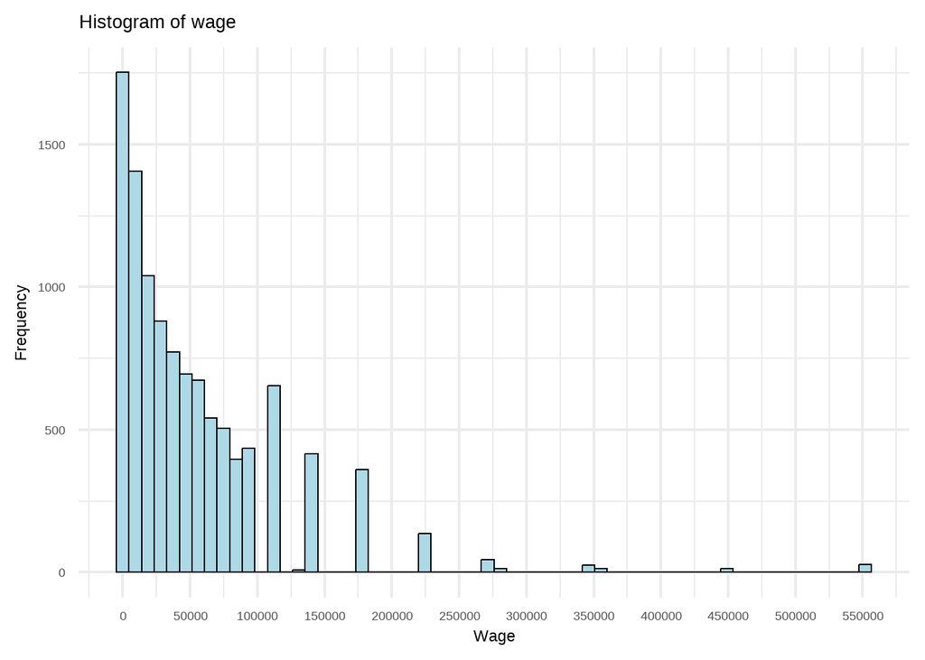

```r
# Plot histogram of wage
ggplot(data, aes(x = wage)) +
  geom_histogram(bins = 60, fill = "lightblue", color = "black") +
  scale_x_continuous(breaks = seq(min(data$wage), max(data$wage), by = 50000)) +
  labs(title = "Histogram of wage", x = "Wage", y = "Frequency") +
  theme_minimal(base_size = 17)
```

Wehen we look at the histogram of the wage we can see that that most of the values are between 0 and 150’000. There are also some values between 150’000 and 250’000. The values above 250’000 are very rare. This is also a bit as expected because wages above 200’000 are not so common as wages to 150’000.

## 1.3 Visualization to display the distribution of the categorial features

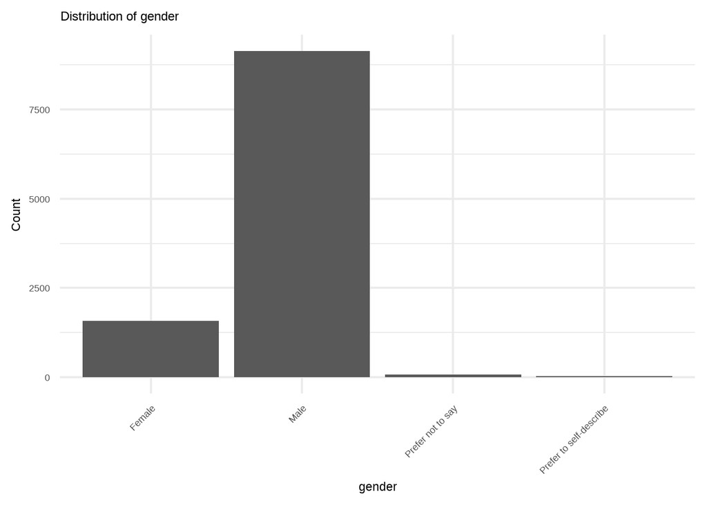

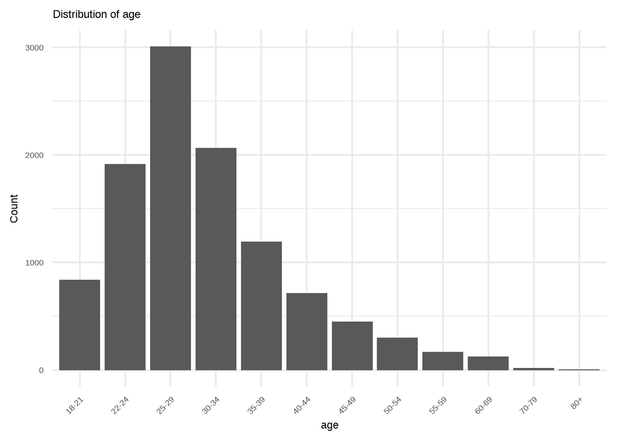

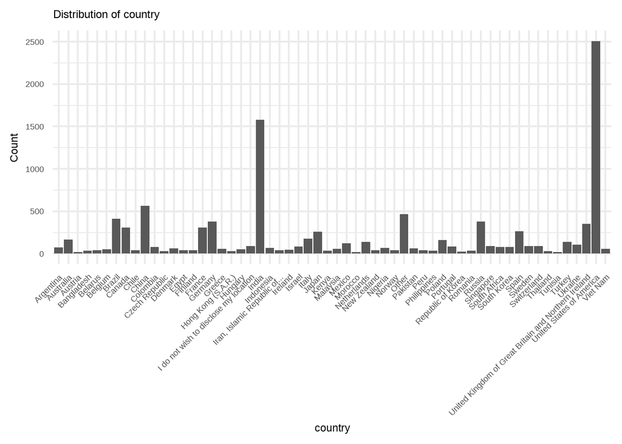

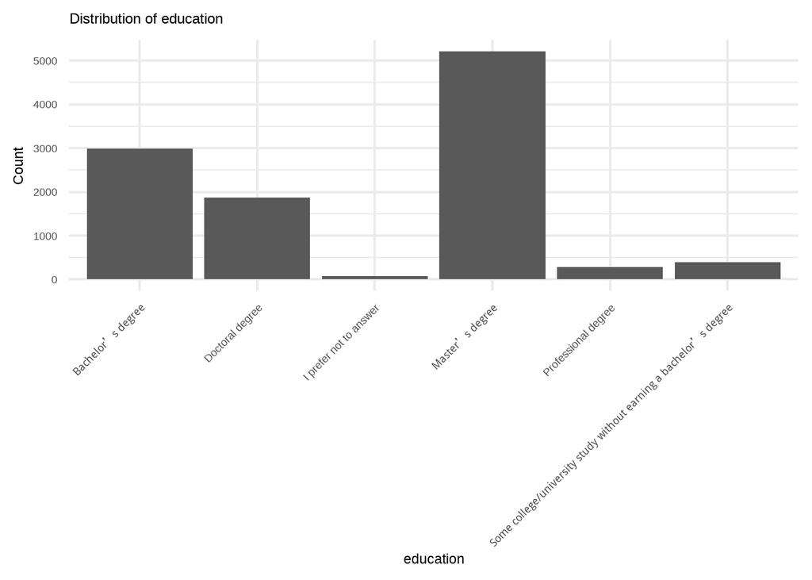

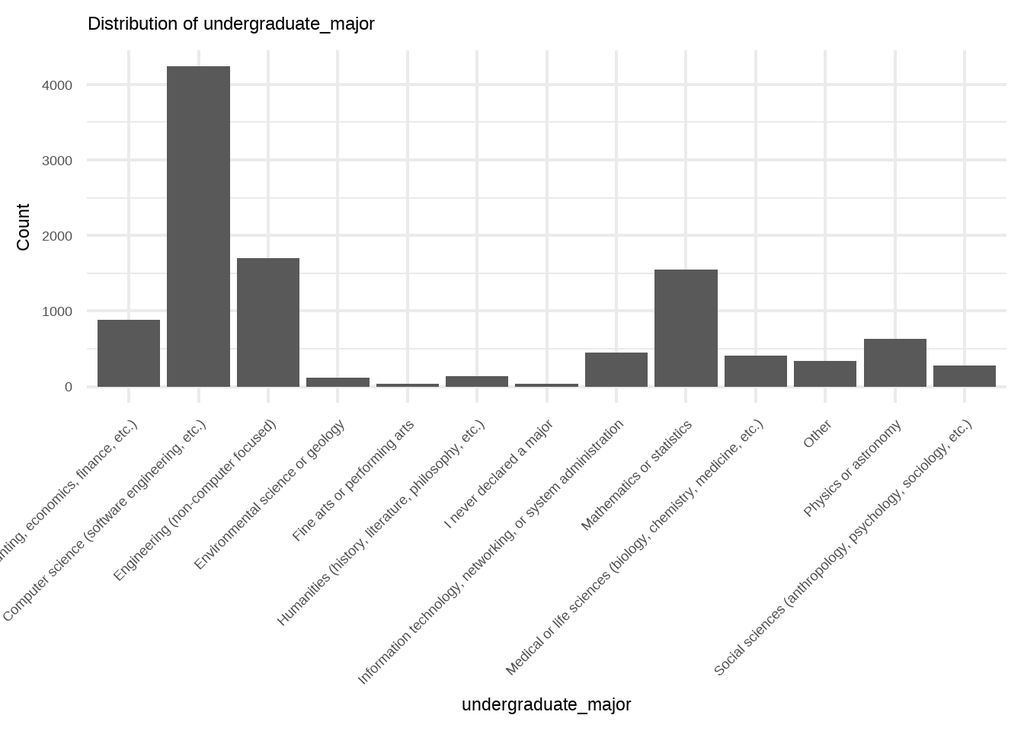

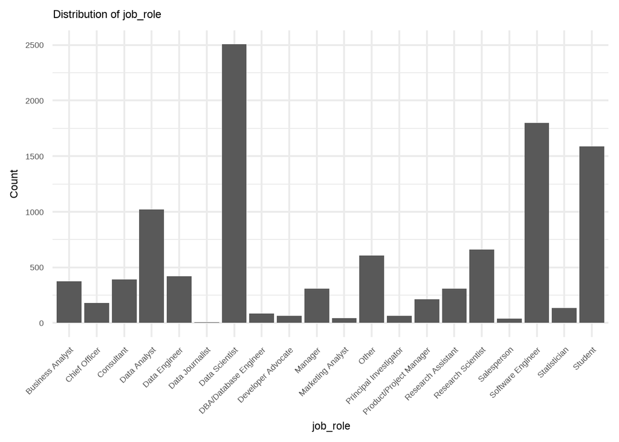

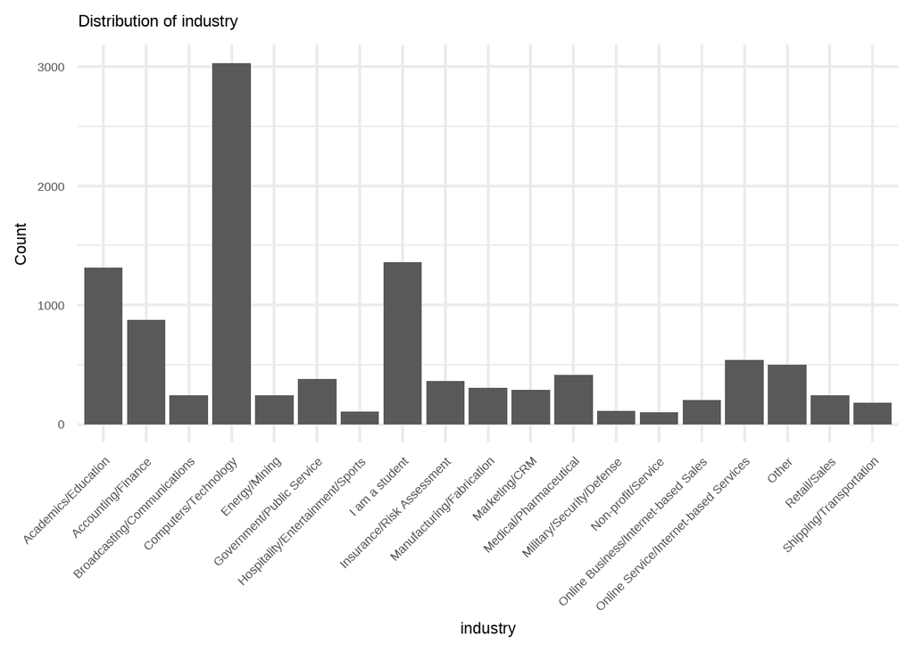

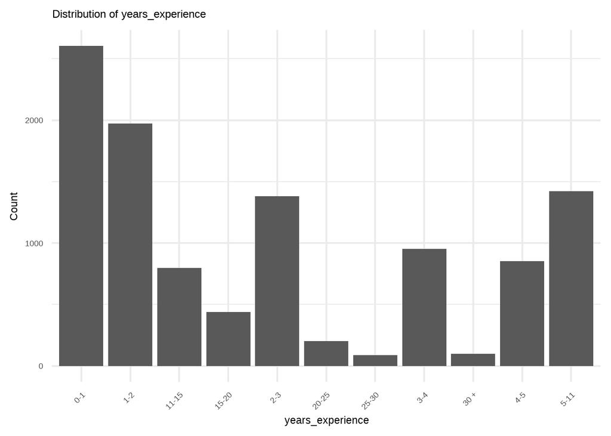

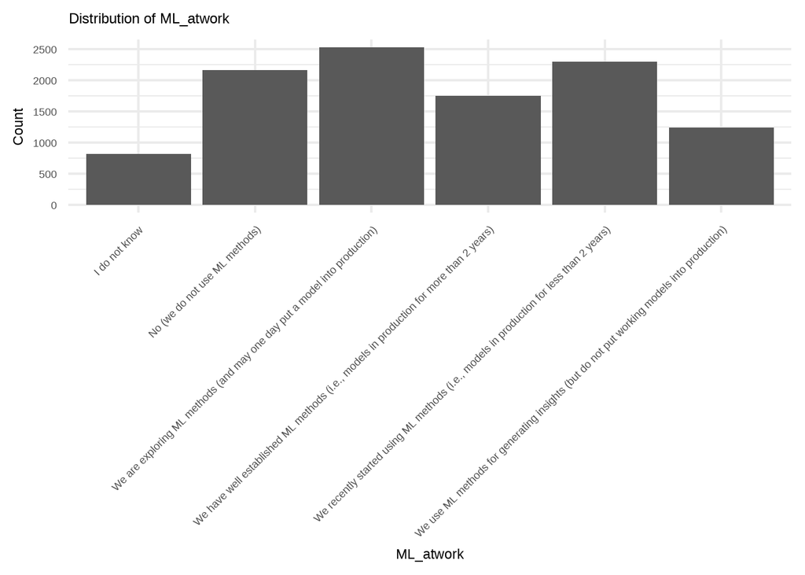

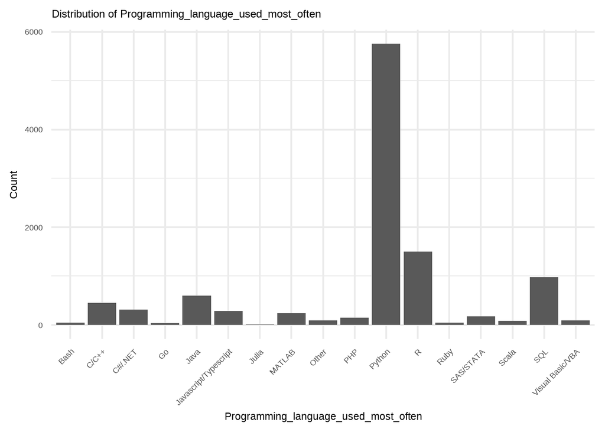

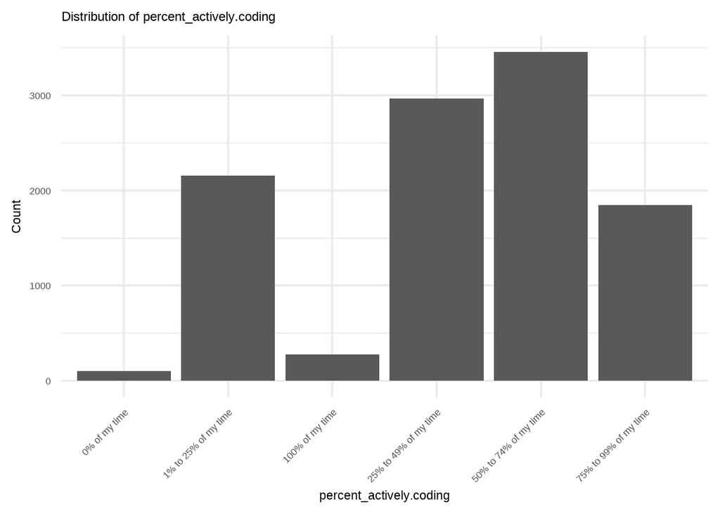

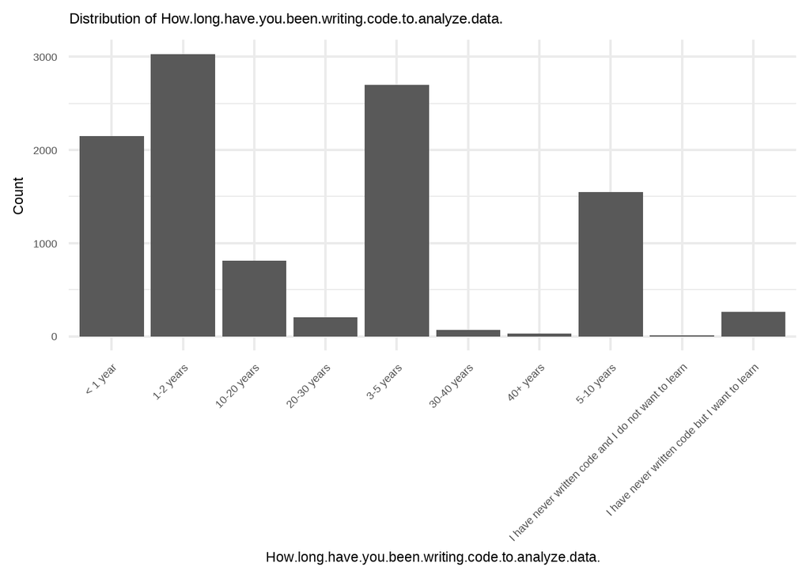

[2 more figures not shown]

```r
# Function to plot bar plots for each categorical variable
plot_categorical_associations <- function(data) {
  categorical_vars <- sapply(data, is.factor) # or is.factor, depending on how data is loaded
  data_categorical <- data[, categorical_vars]

  for(var in names(data_categorical)) {
    # Create the plot and assign it to a variable
    plot <- ggplot(data, aes(x = !!sym(var))) +
      geom_bar(position = "stack") +
      labs(title = paste("Distribution of", var), x = var, y = "Count") +
      theme_minimal(base_size = 17) +
      scale_fill_manual(values=c("#105F77", "#f4a460")) +
      theme(
        axis.text.x = element_text(angle = 45, hjust = 1),
        plot.title = element_text(size = 18)
      )

    # Print the plot
    print(plot)
  }
}

# Apply the function to the loan dataset
plot_categorical_associations(data)
```